# Uso de la API del Covid19 con Pandas

La URL https://api.covid19api.com/countries

### Comentario explicativo

El primer paso para llevar a cabo este trabajo con los datos de la Covid19 es encontrar dichos datos. En la URL adjunta los encontramos en una Interfaz de Acceso Programable (API) que nos va a permitir trabajar con ellos.

## Instalación librerías

```python
!pip install pandas
```

### Comentario explicativo

El siguiente paso es instalar pandas, una biblioteca de software que es la que nos permitirá analizar y manipular los datos de la URL en el lenguaje de programación Phyton. Al inicio hemos utilizado `!`, porque Python lee bash.

## Configuración de Pandas

```python
import pandas as pd
```

### Comentario explicativo

Importamos (`import`) `pandas as pd`. A partir de ahora, podemos utilizar pandas y para ello tendremos que nombrarlo `pd`.

## Crear variable

```python
url = 'https://api.covid19api.com/countries'
```

### Comentario explicativo

Del mismo modo que importamos `pandas as pd`, ahora creamos la variable url `=` el enlace donde encontrábamos los datos tal y como explicamos al inicio del trabajo. Al utilizar `=`, python interpreta que escribir `url`equivale al enlace que se sitúa después de `=`. Entonces, cada vez que queramos utilizar los datos de la url, lo nombramos simplemente con `url`(igual que pandas es `pd`).

## Crear el dataframe

```python
df = pd.read_json(url)
```

```python
df
```

|  | Country | Slug | ISO2 |
| --- | --- | --- | --- |
| 0 | Seychelles | seychelles | SC |
| 1 | Tuvalu | tuvalu | TV |
| 2 | Kiribati | kiribati | KI |
| 3 | Saint Helena | saint-helena | SH |
| 4 | San Marino | san-marino | SM |
| ... | ... | ... | ... |
| 243 | Uruguay | uruguay | UY |
| 244 | South Georgia and the South Sandwich Islands | south-georgia-and-the-south-sandwich-islands | GS |
| 245 | Uzbekistan | uzbekistan | UZ |
| 246 | Haiti | haiti | HT |
| 247 | Lesotho | lesotho | LS |

248 rows × 3 columns

### Comentario explicativo

Creamos un dataframe que nombramos `df` (es lo mismo que hemos hecho con `url`). Este dataframe equivale a los datos de la url, pero para que podamos utilizarlos en Python hemos hecho lo siguiente. Como ya explicamos, es pandas lo que permite que se puedan analizar y manipular los datos en Python, así que lo primero que vamos a hacer es explicitar que los vamos a usar con pandas (`pd`) y dentro de esto vamos a usar la función leer con JSON (JavaScript Objet Notation, el formato, la notación) (`read_json()`). Dentro de la función incluimos el valor de lo que queremos que se lea, es decir los datos: la url `(url)`. El resultado final es `df` (el dataframe, la tabla que resultará después) equivale a usar pandas y leer los datos (`url`) en JSON.

Así hemos hecho la equivalencia (el dataframe `=`a eso) pero para visualizarlo tenemos que ejecutar tan solo `df`. Por eso, al principio, a la derecha pone "in", pero al poner solo `df` como in, sí sale un "out" (es decir, nos devuelve una visualización). Al final de la tabla dice que hay 248 filas y tres columnas. En realidad, hay cuatro columnas (pero una es la de la izquierda que corresponde a la numeración de las filas y por eso no la cuenta). Respecto a las filas, vemos que la numeración acaba en 247: es porque la primera es "0" (luego el total sí son 248).

## Exploración tabla

Aquí exploraremos la tabla para comprender mejor nuestros datos y qué podemos hacer con ellos.

```python
df.head(6)
```

|  | Country | Slug | ISO2 |
| --- | --- | --- | --- |
| 0 | Seychelles | seychelles | SC |
| 1 | Tuvalu | tuvalu | TV |
| 2 | Kiribati | kiribati | KI |
| 3 | Saint Helena | saint-helena | SH |
| 4 | San Marino | san-marino | SM |
| 5 | Singapore | singapore | SG |

### Comentario explicativo

Hemos utilizado la función `head()` para explorar los datos de la cabecera, los primeros datos que poseemos. Lo hemos hecho, igual que lo hicimos para que se leyesen los datos con JSON: `df` (o sea, el dataframe, los datos que estamos leyendo con JSON como explicamos antes) y dentro de este dataframe, la función `head()` y el argumento `(6)`: para que dentro de la cabecera nos muestre los 6 primeros valores. Al escribir una función, si usamos el tabulador, nos da opciones de qué valores podemos introducir en el paréntesis, pero también podríamos haberlo dejado vacío (es decir `df.head()`).

```python
df.tail(2)
```

|  | Country | Slug | ISO2 |
| --- | --- | --- | --- |
| 246 | Haiti | haiti | HT |
| 247 | Lesotho | lesotho | LS |

### Comentario explicativo

Hemos hecho lo mismo que en el paso anterior con la cabecera, pero esta vez con la cola, los valores finales, especificando que se muestren los dos últimos.

```python
df.info()
```

```
<class 'pandas.core.frame.DataFrame'>
RangeIndex: 248 entries, 0 to 247
Data columns (total 3 columns):
 #   Column   Non-Null Count  Dtype
---  ------   --------------  -----
 0   Country  248 non-null    object
 1   Slug     248 non-null    object
 2   ISO2     248 non-null    object
dtypes: object(3)
memory usage: 5.9+ KB
```

### Comentario explicativo

Con la función `info()` nos explica los datos de la tabla. Hay 248 entradas (de 0 a 247, como ya explicamos), de ahí hay 3 columnas (porque esa cuarta es la numeración, no son datos de la tabla) y corresponden a "Country" (0), "Slug" (1) e "ISO2" (2): cada una tiene esos 248 valores no-nulos y tipo de datos = "objeto". También nos explicita del uso de memoria y que es un dataframe de pandas.

```python
df['Country']
```

```
0                                        Seychelles
1                                            Tuvalu
2                                          Kiribati
3                                      Saint Helena
4                                        San Marino
                           ...
243                                         Uruguay
244    South Georgia and the South Sandwich Islands
245                                      Uzbekistan
246                                           Haiti
247                                         Lesotho
Name: Country, Length: 248, dtype: object
```

### Comentario explicativo

Para que solo nos muestre valores concretos del dataframe, explicitamos qué queremos que nos muestre escribiéndolo entre `[]` (en este caso, también entrecomillado porque es texto literal, si no, Python no podría interpretarlo). En este caso, hemos escrito "Country", que, como vimos en el paso anterior, es una de las columnas del dataframe. Al ejecutarlo, solo nos muestra esa columna (los nombres de los países).

```python
df['Country'][66]
```

```
'Honduras'
```

### Comentario explicativo

Siguiendo la lógica del paso anterior, añadimos otro dato entre `[]` para que nos de un valor concreto. Con "Country" solo mostraba los países. Al añadir entre `[]` el 66, nos muestra el valor 66 según la numeración que vemos a la izquierda. El valor devuelto es Honduras (el país nº66 en la lista).

## Tiempo real

https://api.covid19api.com/country/spain/status/confirmed/live

Ahora vamos a utilizar otros datos. Siguiendo con la temática de los datos de la Covid, vamos a ver los casos en tiempo real de tres países. Empezamos con los de España. Igual que hicimos con el primer enlace, en esta URL encontramos la API para los datos en tiempo real de España.

```python
url_es = 'https://api.covid19api.com/country/spain/status/confirmed/live'
df_es = pd.read_json(url_es)
df_es
```

|  | Country | CountryCode | Province | City | CityCode | Lat | Lon | Cases | Status | Date |
| --- | --- | --- | --- | --- | --- | --- | --- | --- | --- | --- |
| 0 | Spain | ES |  |  |  | 40.46 | -3.75 | 0 | confirmed | 2020-01-22 00:00:00+00:00 |
| 1 | Spain | ES |  |  |  | 40.46 | -3.75 | 0 | confirmed | 2020-01-23 00:00:00+00:00 |
| 2 | Spain | ES |  |  |  | 40.46 | -3.75 | 0 | confirmed | 2020-01-24 00:00:00+00:00 |
| 3 | Spain | ES |  |  |  | 40.46 | -3.75 | 0 | confirmed | 2020-01-25 00:00:00+00:00 |
| 4 | Spain | ES |  |  |  | 40.46 | -3.75 | 0 | confirmed | 2020-01-26 00:00:00+00:00 |
| ... | ... | ... | ... | ... | ... | ... | ... | ... | ... | ... |
| 826 | Spain | ES |  |  |  | 40.46 | -3.75 | 11833457 | confirmed | 2022-04-27 00:00:00+00:00 |
| 827 | Spain | ES |  |  |  | 40.46 | -3.75 | 11833457 | confirmed | 2022-04-28 00:00:00+00:00 |
| 828 | Spain | ES |  |  |  | 40.46 | -3.75 | 11833457 | confirmed | 2022-04-29 00:00:00+00:00 |
| 829 | Spain | ES |  |  |  | 40.46 | -3.75 | 11896152 | confirmed | 2022-04-30 00:00:00+00:00 |
| 830 | Spain | ES |  |  |  | 40.46 | -3.75 | 11893480 | confirmed | 2022-05-01 00:00:00+00:00 |

831 rows × 10 columns

### Comentario explicativo

Establecemos las equivalencias con `=` para nombrar la URL y el dataframe igual que explicamos en el caso anterior. Para diferenciarlo de los casos de todos los países con los que estábamos trabajando antes, los llamamos `_es`. Es para abreviar (es=España, así además evitamos la ñ) y no dejar espacios en blanco (no usamos guion medio porque Python lo interpretaría como un signo menos). Despues escribimos `df_es` y ejecutamos para que se visualice, según lo explicado ya anteriormente.

## Exploración

Una vez tenemos ese dataframe,exploraremos los datos tal como hicimos anteriormente.

```python
df_es.columns
```

```
Index(['Country', 'CountryCode', 'Province', 'City', 'CityCode', 'Lat', 'Lon',
       'Cases', 'Status', 'Date'],
      dtype='object')
```

### Comentario explicativo

Con la función `columns`, sabemos cuáles son las columnas de nuestro dataframe.

```python
df_es['Date'].head(1)
```

```
0   2020-01-22 00:00:00+00:00
Name: Date, dtype: datetime64[ns, UTC]
```

### Comentario explicativo

Tal como vimos anteriormente, con `[]` solo se nos muestra ese valor. En este caso, escogemos la columna "Date", las fechas. Después, usamos la función `head()`, ya explicada anteriormente y, concretamente, explicitamos que queremos solo el primer valor. Por tanto, nos devuelve, solo dentro de la columna de fechas, el primer valor de la tabla. La interpretación de este dato es la fecha en que comienza a contabilizar los casos de Covid en España.

```python
df_es.info()
```

```
<class 'pandas.core.frame.DataFrame'>
RangeIndex: 831 entries, 0 to 830
Data columns (total 10 columns):
 #   Column       Non-Null Count  Dtype
---  ------       --------------  -----
 0   Country      831 non-null    object
 1   CountryCode  831 non-null    object
 2   Province     831 non-null    object
 3   City         831 non-null    object
 4   CityCode     831 non-null    object
 5   Lat          831 non-null    float64
 6   Lon          831 non-null    float64
 7   Cases        831 non-null    int64
 8   Status       831 non-null    object
 9   Date         831 non-null    datetime64[ns, UTC]
dtypes: datetime64[ns, UTC](1), float64(2), int64(1), object(6)
memory usage: 65.0+ KB
```

Usamos la función `info()` que nos explica el tipo y número de datos que hay en la tabla, las columnas que tiene... como ya explicamos en el caso anterior.

```python
df_es.describe()
```

|  | Lat | Lon | Cases |
| --- | --- | --- | --- |
| count | 8.310000e+02 | 831.00 | 8.310000e+02 |
| mean | 4.046000e+01 | -3.75 | 3.527601e+06 |
| std | 7.109706e-15 | 0.00 | 3.417718e+06 |
| min | 4.046000e+01 | -3.75 | 0.000000e+00 |
| 25% | 4.046000e+01 | -3.75 | 3.509475e+05 |
| 50% | 4.046000e+01 | -3.75 | 3.188553e+06 |
| 75% | 4.046000e+01 | -3.75 | 4.968352e+06 |
| max | 4.046000e+01 | -3.75 | 1.189615e+07 |

La función `describe()` nos devuelve algunos datos estadísticos estándar sobre nuestro dataframe, como el mínino y el máximo, el 25, 50 y 75%, etc. En este caso, solo mantiene las columnas "lat", "lon" y "cases" porque son las que contienen valores numéricos.La latitud y la longitud, como interpretación de los datos, no nos serviría en realidad.

```python
df_es
```

|  | Country | CountryCode | Province | City | CityCode | Lat | Lon | Cases | Status | Date |
| --- | --- | --- | --- | --- | --- | --- | --- | --- | --- | --- |
| 0 | Spain | ES |  |  |  | 40.46 | -3.75 | 0 | confirmed | 2020-01-22 00:00:00+00:00 |
| 1 | Spain | ES |  |  |  | 40.46 | -3.75 | 0 | confirmed | 2020-01-23 00:00:00+00:00 |
| 2 | Spain | ES |  |  |  | 40.46 | -3.75 | 0 | confirmed | 2020-01-24 00:00:00+00:00 |
| 3 | Spain | ES |  |  |  | 40.46 | -3.75 | 0 | confirmed | 2020-01-25 00:00:00+00:00 |
| 4 | Spain | ES |  |  |  | 40.46 | -3.75 | 0 | confirmed | 2020-01-26 00:00:00+00:00 |
| ... | ... | ... | ... | ... | ... | ... | ... | ... | ... | ... |
| 826 | Spain | ES |  |  |  | 40.46 | -3.75 | 11833457 | confirmed | 2022-04-27 00:00:00+00:00 |
| 827 | Spain | ES |  |  |  | 40.46 | -3.75 | 11833457 | confirmed | 2022-04-28 00:00:00+00:00 |
| 828 | Spain | ES |  |  |  | 40.46 | -3.75 | 11833457 | confirmed | 2022-04-29 00:00:00+00:00 |
| 829 | Spain | ES |  |  |  | 40.46 | -3.75 | 11896152 | confirmed | 2022-04-30 00:00:00+00:00 |
| 830 | Spain | ES |  |  |  | 40.46 | -3.75 | 11893480 | confirmed | 2022-05-01 00:00:00+00:00 |

831 rows × 10 columns

```python
df_es.set_index('Date')
```

| Date | Country | CountryCode | Province | City | CityCode | Lat | Lon | Cases | Status |
| --- | --- | --- | --- | --- | --- | --- | --- | --- | --- |
| 2020-01-22 00:00:00+00:00 | Spain | ES |  |  |  | 40.46 | -3.75 | 0 | confirmed |
| 2020-01-23 00:00:00+00:00 | Spain | ES |  |  |  | 40.46 | -3.75 | 0 | confirmed |
| 2020-01-24 00:00:00+00:00 | Spain | ES |  |  |  | 40.46 | -3.75 | 0 | confirmed |
| 2020-01-25 00:00:00+00:00 | Spain | ES |  |  |  | 40.46 | -3.75 | 0 | confirmed |
| 2020-01-26 00:00:00+00:00 | Spain | ES |  |  |  | 40.46 | -3.75 | 0 | confirmed |
| ... | ... | ... | ... | ... | ... | ... | ... | ... | ... |
| 2022-04-27 00:00:00+00:00 | Spain | ES |  |  |  | 40.46 | -3.75 | 11833457 | confirmed |
| 2022-04-28 00:00:00+00:00 | Spain | ES |  |  |  | 40.46 | -3.75 | 11833457 | confirmed |
| 2022-04-29 00:00:00+00:00 | Spain | ES |  |  |  | 40.46 | -3.75 | 11833457 | confirmed |
| 2022-04-30 00:00:00+00:00 | Spain | ES |  |  |  | 40.46 | -3.75 | 11896152 | confirmed |
| 2022-05-01 00:00:00+00:00 | Spain | ES |  |  |  | 40.46 | -3.75 | 11893480 | confirmed |

831 rows × 9 columns

### Comentario explictivo

Explorando los datos, hemos llegado a la conclusión que lo más interesante para redactar una historia periodística serían la fecha y el número de casos (el resto de valores son siempre los mismos: país España con sus respectivas cordenadas y el estado de casos "confirmados").

El primer paso para centrarnos en ellos es establecer "date" cómo índice, es decir la primera columna. Lo aplicamos con la función `set_index()` y entre `()` el valor de lo que queremos que se convierta en ese índice, en este caso la columna "Date", las fechas.

```python
df_es.set_index('Date')['Cases']
```

```
Date
2020-01-22 00:00:00+00:00           0
2020-01-23 00:00:00+00:00           0
2020-01-24 00:00:00+00:00           0
2020-01-25 00:00:00+00:00           0
2020-01-26 00:00:00+00:00           0
                               ...
2022-04-27 00:00:00+00:00    11833457
2022-04-28 00:00:00+00:00    11833457
2022-04-29 00:00:00+00:00    11833457
2022-04-30 00:00:00+00:00    11896152
2022-05-01 00:00:00+00:00    11893480
Name: Cases, Length: 831, dtype: int64
```

### Comentario explicativo

Una vez hemos establecido que "date" sea el índice, entre `[]` (como explicamos anteriormente) decimos que solo nos muestre "Cases", el número de casos, que es el otro dato que nos interesaba.

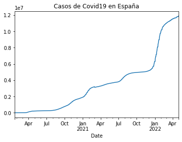

```python
df_es.set_index('Date')['Cases'].plot(title="Casos de Covid19 en España")
```

### Comentario explicativo

Ya hemos establecido que en el dataframe hay un "index" que son las fechas y, dentro de él, queremos que solo muestre los valores del número de casos (entre `[]`, "Cases"). Sobre esto, vamos a crear una visualización con una nueva función: `plot()`. Para añadir la función a aquello, escribimos un punto y el nombre de `plot()`, siguiendo la lógica del resto de funciones que ya hemos empleado. Dentro del argumento, tenemos varias opciones (las visualizamos con el tabulador). En este caso, queremos que el gráfico que estamos creando tenga un título, así que escribimos `title` seguido del `=` (para establecer la equivalencia, lo que es el título que se mostrará es lo que viene a continuación) y entre comillas (porque es texto literal) cómo queremos que se llame nuestro gráfico.

El resultado es un gráfico de línea en el cual el eje x es el "index" que habíamos establecido, las fechas; y el eje de las y los valores que queríamos extraer de ahí, es decir, el nº de casos. Posee el título que explicitamos al escribir como argumento de `plot(title="Casos de Covid19 en España")`.

## Otro país

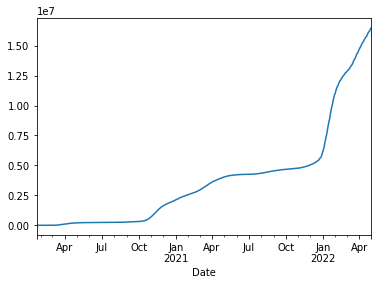

```python
url_it = 'https://api.covid19api.com/country/italy/status/confirmed/live'
df_it = pd.read_json(url_it)
df_it.set_index('Date')['Cases'].plot()
```

### Comentario explicativo

Hemos hecho lo mismo que hicimos para España esta vez con los datos de Italia. Al nombrarlos, en lugar del `_es`, ponemos it (abreviatura de Italia) y el enlace a los datos corresponde a la API de Italia, en lugar de España. Además, para ahorrar pasos, después de nombrar la url y el df, directamente escribimos en un solo paso que establezca el index en "Date", dentro de ello solo use los valores "Cases" y con la función `plot()`, los muestre en el gráfico. Hemos dejado vacío el argumento, así que no hay título en este caso.

## Otro país (propio)

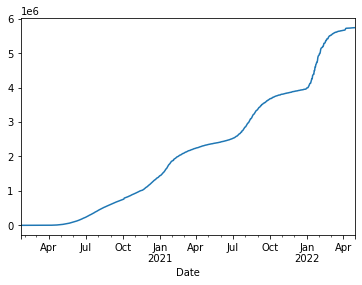

```python
url_mx = 'https://api.covid19api.com/country/mexico/status/confirmed/live'
df_mx = pd.read_json(url_mx)
df_mx.set_index('Date')['Cases'].plot()
```

### Comentario explicativo

Como hicimos con Italia, escogemos el país México para ver sus datos, siguiendo los mismos pasos que acabamos de explicar. A la hora de nombrarlo, tras el guion bajo hemos escogido "mx" como abreviatura de México.

## Comparativa

```python
casos_mx = df_mx.set_index('Date')['Cases']
casos_it = df_it.set_index('Date')['Cases']
casos_es = df_es.set_index('Date')['Cases']
```

### Comentario explicativo

Ahora vamos a comparar los datos de los tres países. El primer paso es dar un nombre a los datos de cada uno de ellos una vez hemos seleccionado los datos que nos interesan ("Date" como índice y dentro de esto los valores de "Cases"). A cada dataframe lo llamamos `casos_` y la abreviatura que usamos en los pasos anteriores (es, it, mx).

```python
casos_es
```

```
Date
2020-01-22 00:00:00+00:00           0
2020-01-23 00:00:00+00:00           0
2020-01-24 00:00:00+00:00           0
2020-01-25 00:00:00+00:00           0
2020-01-26 00:00:00+00:00           0
                               ...
2022-04-27 00:00:00+00:00    11833457
2022-04-28 00:00:00+00:00    11833457
2022-04-29 00:00:00+00:00    11833457
2022-04-30 00:00:00+00:00    11896152
2022-05-01 00:00:00+00:00    11893480
Name: Cases, Length: 831, dtype: int64
```

### Comentario explicativo

Hemos escrito uno de ellos para que nos lo "imprima" y simplemente comprobar que está bien, como es el caso.

```python
pd.concat([casos_es,casos_it,casos_mx],axis=1)
```

| Date | Cases | Cases | Cases |
| --- | --- | --- | --- |
| 2020-01-22 00:00:00+00:00 | 0 | 0 | 0 |
| 2020-01-23 00:00:00+00:00 | 0 | 0 | 0 |
| 2020-01-24 00:00:00+00:00 | 0 | 0 | 0 |
| 2020-01-25 00:00:00+00:00 | 0 | 0 | 0 |
| 2020-01-26 00:00:00+00:00 | 0 | 0 | 0 |
| ... | ... | ... | ... |
| 2022-04-27 00:00:00+00:00 | 11833457 | 16279754 | 5736579 |
| 2022-04-28 00:00:00+00:00 | 11833457 | 16349788 | 5737811 |
| 2022-04-29 00:00:00+00:00 | 11833457 | 16409183 | 5738769 |
| 2022-04-30 00:00:00+00:00 | 11896152 | 16463200 | 5739680 |
| 2022-05-01 00:00:00+00:00 | 11893480 | 16504791 | 5739680 |

831 rows × 3 columns

### Comentario explicativo

Queremos concatenar los datos de los tres dataframes. `pd.concat` significa concatenar objetos de pandas (que al principio del todo establecimos que íbamos a nombrar como `pd`), concatenar es la función que aplicamos. Como es una función, va seguida de su argumento entre `()`. La primera parte del argumento, entre `[]` los dataframes que queremos concatenar (los de los tres países con los nombres que les dimos en el paso anterior) y después, establecemos que el `axis=1`, es decir, el eje va a ser esa columna "Date", la primera porque la establecimos como índice. Que 1 sea "columns" es la manera de utilizar la función dentro de Python.

```python
vs = pd.concat([casos_es,casos_it,casos_mx],axis=1)
```

```python
vs
```

| Date | Cases | Cases | Cases |
| --- | --- | --- | --- |
| 2020-01-22 00:00:00+00:00 | 0 | 0 | 0 |
| 2020-01-23 00:00:00+00:00 | 0 | 0 | 0 |
| 2020-01-24 00:00:00+00:00 | 0 | 0 | 0 |
| 2020-01-25 00:00:00+00:00 | 0 | 0 | 0 |
| 2020-01-26 00:00:00+00:00 | 0 | 0 | 0 |
| ... | ... | ... | ... |
| 2022-04-27 00:00:00+00:00 | 11833457 | 16279754 | 5736579 |
| 2022-04-28 00:00:00+00:00 | 11833457 | 16349788 | 5737811 |
| 2022-04-29 00:00:00+00:00 | 11833457 | 16409183 | 5738769 |
| 2022-04-30 00:00:00+00:00 | 11896152 | 16463200 | 5739680 |
| 2022-05-01 00:00:00+00:00 | 11893480 | 16504791 | 5739680 |

831 rows × 3 columns

### Comentario explicativo

Llamamos a esa concatenación de los dataframes `vs` (por "versus"). Cuando lo escribimos solo se nos muestra. Hemos hecho bien la concatenación, como índice esta "Date" y después otras tres columnas con los casos de cada país. Pero todas se llaman "Cases" (que es como se llamaban en el dataframe de origen).

```python
vs.columns
```

```
Index(['Cases', 'Cases', 'Cases'], dtype='object')
```

### Comentario explicativo

Con la función `columns` vemos que las tres se llaman "Cases" (dentro del Index que ya hemos explicado que son las fechas). La función también nos muestra el Data Type.

```python
vs.columns = ['España','Italia','México']
```

### Comentario explicativo

Para cambiar el nombre de las columnas usamos `=`, como ya lo hemos usado en otras ocasiones. Entonces `vs.columns` (las columnas del dataframe vs, el concatenado, usando la función que explicamos antes) son `=` "España", "Italia" y "México" entre `[]`, igual que en el paso anterior aparecía tres veces la palabra "Cases".

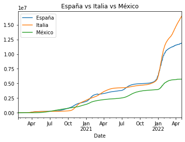

```python
vs.plot(title="España vs Italia vs México")
```

### Comentario explicativo

Usamos la función `plot` sobre el dataframe `vs` para que se pinte un gráfico. Como argumento escribimos `title=` para introducir el título de la misma manera en que lo hicimos y explicamos al hacer los gráficos individuales de cada país. Se pinta una línea por cada columna (excluyendo el índice, que es el eje): España, Italia y México, con su respectiva leyenda por colores. El resto de la descripción del gráfico es análogo al de los casos de los países individualmente.

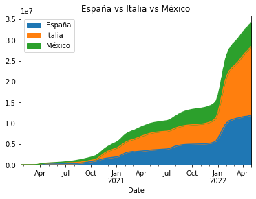

```python
vs.plot(title="España vs Italia vs México", kind='area')
```

### Comentario explicativo

Por defecto, al pintar el gráfico, había hecho un gráfico de líneas, pero Python también nos permite otros formatos. Para establecerlos, tenemos que escribir, dentro del argumento de la función `plot()`, `kind=` al tipo que queramos. Como también habíamos usado `title=`, lo escribimos a continuación seguido de una coma. En este caso hemos escogido "area". Personalmente, a la hora de aplicarlo a una información real, creo que sería más correcto el de líneas para este tipo de datos.

```python
vs.to_csv('esvsitvsmx.csv')
```

### Comentario explicativo

Ya terminamos de manipular los datos y queremos descargar lo que hemos hecho. Para descargar los datos vamos a convertir vs (el dataframe de la comparación) en csv con la funcón `to_` seguido del formato en que lo convertimos, en este caso `to_csv`. Como argumento de la función, el nombre con el que queremos que se guarde. Es importante no olvidar poner .csv para que se guarde correctamente en el formato escogido. Va entre comillas porque es texto literal.

```python
!ls
```

```
api-pandas-folium.ipynb  python-api-covid19-pandas.ipynb
esvsitvsmx.csv		 python-api-libre-pandas.ipynb
esvsitvsmx.png		 python-pruebas.ipynb
Notas.ipynb		 Shared_Resources
practica-4.csv
```

Usando `ls`, el comando de bash (por eso va precedido de `!`), vemos (listamos) los documentos que tenemos. Si aparece el nombre que hemos guardado en el paso anterior, es que lo hemos hecho correctamente, como es el caso.

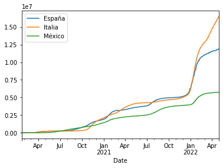

```python
import matplotlib.pyplot as plt
vs.plot()
plt.savefig('esvsitvsmx.png')
```

### Comentario explicativo

Para descargar los gráficos, imágenes, hay que seguir un procedimiento diferente. Primero hemos importado `matpltlib.pyplot` que es lo que nos permite ver esos gráficos. Lo importamos como (`as`) `plt`, que será el nombre que utilicemos, por tanto, para nombrarlo. Es un proceso análogo al que hicimos al principio con pandas (`as pd`). Después pintamos vs con la función `plot()` como ya hemos explicado. Una vez hemos hecho los dos pasos anteriores, usamos `plt` (`matplotlib.pyplot`) con la función `savefig()` que es lo que nos permite guardar esa imagen. Igual que con los datos, el argumento de la función es el nombre con que se guardará la imagen. En este caso ponemos `.png` para que se guarden correctamente en el formato.

```python
!ls
```

```
api-pandas-folium.ipynb  practica-4.csv			  python-pruebas.ipynb
esvsitvsmx.csv		 practica-4.png			  Shared_Resources
esvsitvsmx.png		 python-api-covid19-pandas.ipynb
Notas.ipynb		 python-api-libre-pandas.ipynb
```

### Comentario explicativo

Volvimos a hacer `!ls` para comprobar que el gráfico se había guardado correctamente tal como hicimos con los datos en csv